# SDS Project 1: Global Emissions

Mark Herndon

2023-09-18

# Question 1

**Abstract**

> Growing trends in global greenhouse gas emissions contribute heavily to the warming of the Earth. Comprised of the greenhouse gas emissions is Carbon Dioxide (CO2) which is emitted through the burning of fossil fuels, and Nitrous Oxide (N2O) which is primarily produced through agricultural production and land managment. As these Greenhouse gas emissions grow into the composition of our atmosphere, the Earth’s Ozone layer deterioates leading to the warming of the planets climate. Compariatively, studies done on the compund Nitrous Oxide reveal that one pound of Nitrous Oxide warms the atmosphere around 300 times as much as Carbon dioxide over a 100 year life-span. Along with these studies, found that most Nitrous Oxide emissions amount from Land and Agricultural management.**

> In this study we will be analyzing the total greenhouse gas emissions of Nitrous Oxide and Carbon Dioxide, and if those emissions correlate to a country’s GDP and Population, as well as how the total emissions compare within global regions. To produce our findings, we will be using data from the *Our World in Data* organization, which gives us information on a country and their emissions for Carbon Dioxide and Nitrous Oxide, along with their population, GDP, and regions of the Americas, Eurpoe, Asia, and the Middle East.**

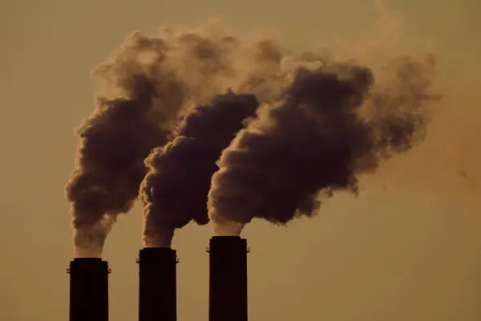

*Image 1.Photo of Emissions. The New York Times, https://www.nytimes.com/. Accessed 19 Sept. 2023.*

> First, for reference on the make-up of the total emissions for these countries, we should look at how the data of Nitrous Oxide and Carbon Dioxide is proportioned:

Total Emissions of N2O compared to C2O On A Global Scale

| Region | Total N2O Emissions | Total CO2 Emissions |
| --- | --- | --- |
| Africa | 160.94 | 1167.275 |
| Americas | 664.77 | 7510.125 |
| Asia/Pacific | 1160.43 | 16799.620 |
| Europe | 386.36 | 5954.784 |
| Middle east | 168.86 | 2800.918 |

> From this table, we can see how a large makeup of the total Greenhouse gas emissions is overwhelmingly CO2. Now lets see the distribution of our outcome varibale of the total emissions produced by countries.

# Question 2

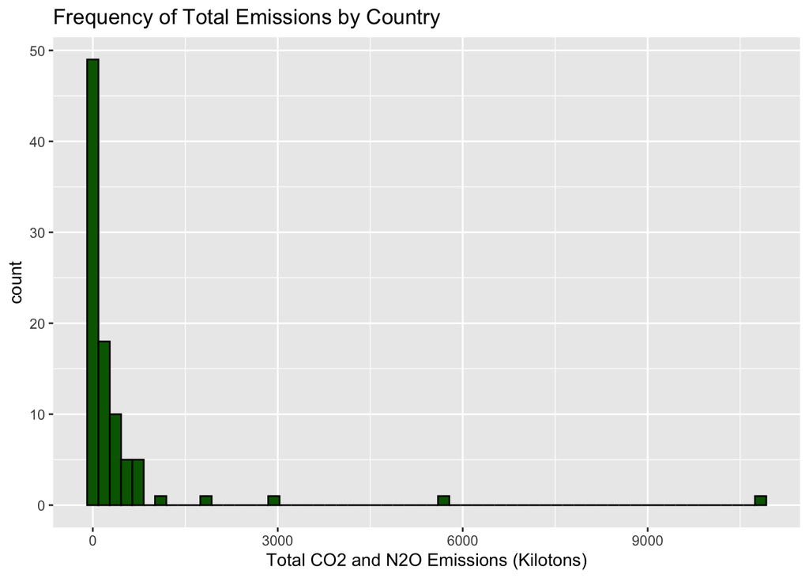

```
## [1]     4.043    35.863    74.640   294.155 10835.179
```

```
## [1] 399.7183
```

```
## [1] 1297.271
```

# Question 3

> Now we can investigate predictor variables to see how they correlate with our outcome variable. First lets compare total emissions to Countries Population:

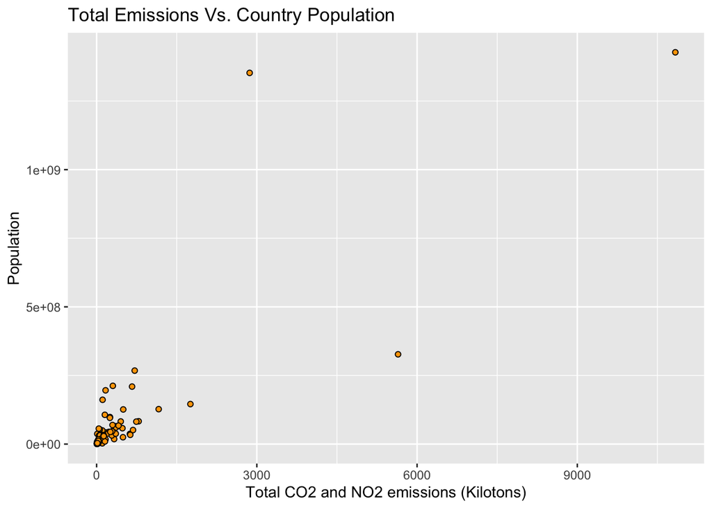

```
## [1] 0.821052
```

```
## [1]     4.043    35.863    74.640   294.155 10835.179
```

> From this plotted graph we can see a positive correlation between total emissions and Population. This is further back by a correlation coefficient of 0.821052, This positive relation and a correlation coefficient close to 1 suggests that there is a strong relationship between total emissions from countries and their populations.

> _-Now lets compare total emissions from countries compared to their GDP:

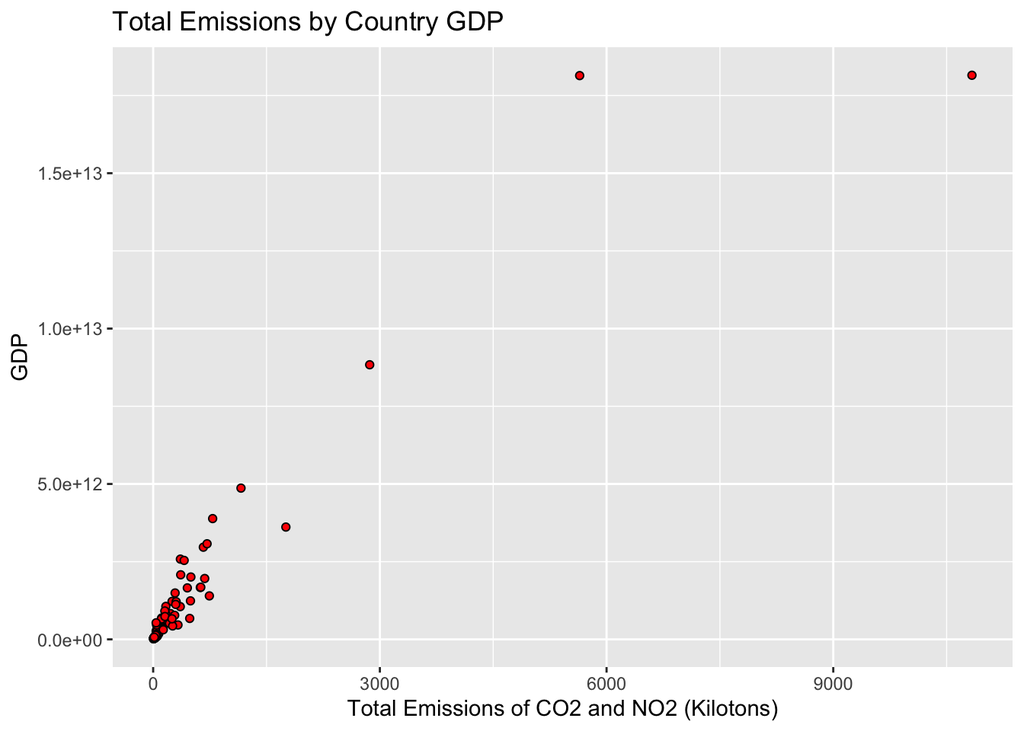

```
## [1] 0.937856
```

```
## [1]     4.043    35.863    74.640   294.155 10835.179
```

> Now finally we’ll compare global regions to total emissions and see how they compare against eachother.

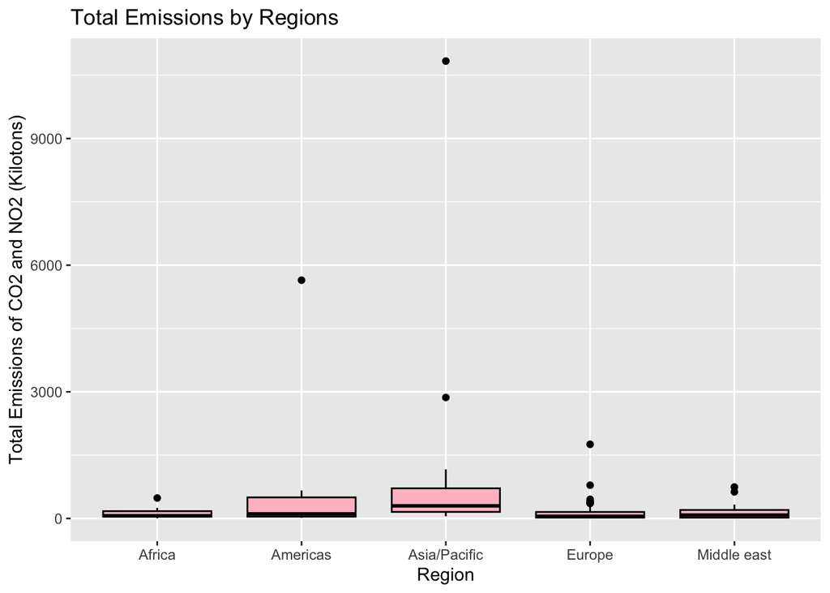

# Question 4

Sources:

https://www.ncbi.nlm.nih.gov/pmc/articles/PMC5692531/

https://www.epa.gov/ghgemissions/sources-greenhouse-gas-emissions

https://ourworldindata.org/co2-and-greenhouse-gas-emissions